# Построение маршрута

Для построения маршрута необходимо выбрать две точки:

- начальное положение;
- пункт назначения.

# Используемые библиотеки

```python
import networkx as nx
import pyproj
import numpy as np
import pandas as pd
import osmnx as ox
import geopy
import geopandas as gpd
import folium
ox.config(use_cache=True, log_console=True)
```

## Загрузка данных

```python
parking_data = gpd.read_file(r'data_sets\parkings.gpkg')
speed_limit_zones = gpd.read_file(r'data_sets\speed_limit_zones.gpkg')
forbidden_zones = gpd.read_file(r'data_sets\forbidden_zones.gpkg')
scooters = pd.read_csv('data_sets\scooters.cvs')
```

# Получение маршрута

Для построения графа дорог необходимо использовать метод `graph_from_address` или `graph_from_points` из библиотеки `osmnx`.

```python
def create_graph(loc, dist, transport_mode, loc_type="address"):
    if loc_type == "address":
            G = ox.graph_from_address(loc, dist=dist, network_type=transport_mode)
    elif loc_type == "points":
            G = ox.graph_from_point(loc, dist=dist, network_type=transport_mode )
    return G # Возвращение графа дорог
```

`loc` - наименование населенного пункта (тип `string`),

`dist` - радиус отображения графа от центра (в метрах),

`transport_mode` - тип графа

```python
def get_route(G, start, end):

    G = ox.add_edge_speeds(G) #Impute
    G = ox.add_edge_travel_times(G) #Travel time

    start_node = ox.distance.nearest_edges(G, start.x, start.y) # Определение ID-node начальной точки
    end_node = ox.nearest_edges(G, end.x, end.y) # Определение ID-node конечной точки

    start_node = start_node[start_node[2]]
    end_node = end_node[end_node[2]]

    # Calculate the shortest path
    route = nx.shortest_path(G, start_node, end_node, weight='time') # Получение ID-node - точек маршрута

    return route
```

Формирование графа

```python
G = create_graph('Moscow', 2000, 'walk')
```

Формирование карты с графом дорог

```python
m = ox.plot_graph_folium(G)
```

## Удаление запретных зон из графа

```python
def define_forbidden_graphs(forbidden_zones):
    forbidden_graphs = []
    for i in range(len(forbidden_zones.geometry)):
            p = ox.graph_from_polygon(forbidden_zones.geometry[i])
            forbidden_graphs.append(p)
    return forbidden_graphs
```

```python
forbidden_graphs = define_forbidden_graphs(forbidden_zones=forbidden_zones)
```

```python
for i in range(len(forbidden_graphs)):
    try:
        G.remove_nodes_from(forbidden_graphs[i])
    except:
        pass
```

```python
m_2 = ox.plot_graph_folium(G)
```

# Расчет маршрутов между парковками

```python
def routes_estimator(parkings):
    parkings_coordinates = parkings.geometry # данные по геолокации между точками
    all_routes = [] # сохранение данных по маршрутам в массиве -index: номер парковки, значение: массив с маршрутами
    for i in range(len(parkings_coordinates[:len(parkings_coordinates)-1])):
        current_parking = parkings_coordinates[i]
        current_route = []
        for other_parking in parkings_coordinates[i+1:]:
            try:
                current_route.append(get_route(G, current_parking, other_parking))
            except Exception as e:
                print('Error:', e)
        all_routes.append(current_route)
    return all_routes
```

# Определение ближайшей парковки

Данные по скутерам на парковках представлены по разным периодам, поэтому для моделирования динамического изменения числа самокатов на парковах будет использоваться случайный выбор среза по дате в исходном датасете

```python
def get_scooters_at_parkings():
    try:
        scooters = pd.read_csv('data_sets\scooters.cvs')
        scooters = scooters.rename(columns={'Unnamed: 0': 'id'})
        random_date = np.random.choice(scooters.ts_utc.unique())
    except Exception as e:
        print(f'{e}')
    return scooters[(scooters['ts_utc'] == random_date) & scooters['scooters_at_parking'] > 0]
```

a) нахождение близлежащих парковок самокатов от точки по радиусу

```python
def find_nearest_parkings(lat, lon, parking_data, r):

    LAT_OFFSET = r/1110 # в 1 градусе широты 111 км - преобразование метров в градусы
    LON_OFFSET = r/1113 # в 1 градусе долготы 111.3 км

    # радиус (погрешность примерно 30м)

    lat_min = lat - LAT_OFFSET
    lon_min = lon - LON_OFFSET

    lat_max = lat + LAT_OFFSET
    lon_max = lon + LAT_OFFSET

    lon_condition = (parking_data.geometry.y >= lon_min) & (parking_data.geometry.y <= lon_max)
    lat_condition = (parking_data.geometry.x >= lat_min) & (parking_data.geometry.x <= lat_max)

    return parking_data[lon_condition & lat_condition].drop_duplicates()
```

б) определение ближайшей парковки к пользователю

```python
def get_nearest_parkings(point, parking_data, r=2.5):
    nearest_parkings = find_nearest_parkings(point[1], point[0], parking_data, r)
    return nearest_parkings.reset_index(drop=True)
```

Получение id и geo парковок, находящихся в радиусе указанной координаты

```python
nearest_parkings = get_nearest_parkings((55.756208, 37.588267), parking_data, r=3.5)
nearest_parkings
```

|  | id | geometry |
| --- | --- | --- |
| 0 | 2052 | POINT (37.58709 55.75829) |
| 1 | 100526 | POINT (37.58664 55.75744) |
| 2 | 100527 | POINT (37.58975 55.75616) |
| 3 | 100530 | POINT (37.59025 55.75866) |
| 4 | 104309 | POINT (37.58667 55.75345) |
| 5 | 122698 | POINT (37.58659 55.75393) |
| 6 | 157150 | POINT (37.58902 55.75782) |

Получение данных о количестве самокатов на текущий момент

```python
scooters = get_scooters_at_parkings()
```

```python
power_data = scooters['power_list'].apply(lambda x: x[1:-1].split(','))
```

```python
power_data
```

```
2395     [0.2,  0.33,  0.69]
2397                   [0.4]
2398    [0.46,  0.17,  0.68]
2400                  [0.49]
2401     [0.8,  0.44,  0.12]
                ...
4878                  [0.27]
4879    [0.67,  0.42,  0.73]
4883                  [0.25]
4887                  [0.82]
4889                   [0.7]
Name: power_list, Length: 856, dtype: object
```

```python
def get_powered_parkings(avalebal_parkings, min_power=0.3): # min_power должен рассчитываться из расчета: уровень заряда батареи на км пути
    power_indexes = []
    for power_index in power_data[power_data.index.isin(avalebal_parkings['id'])].index:
        if min((list(map(float, power_data[power_index])))) > min_power:
            power_indexes.append(power_index)
    return(pd.Series(power_indexes))
```

Определение индексов парковок, на которых есть самокаты рядом с пользователем

```python
avalebal_parkings = scooters[(scooters.parking_id.isin(nearest_parkings.id)) & (scooters['scooters_at_parking'] > 0)]
avalebal_parkings_id = avalebal_parkings[avalebal_parkings['id'].isin(get_powered_parkings(avalebal_parkings))]['parking_id']
avalebal_parkings_id
```

```
4781    157150
Name: parking_id, dtype: int64
```

```python
avalibel_start_parkings = nearest_parkings[nearest_parkings.id.isin(avalebal_parkings_id)]
avalibel_start_parkings
```

|  | id | geometry |
| --- | --- | --- |
| 6 | 157150 | POINT (37.58902 55.75782) |

Определение ближайших парковок к пользователю, для примера возьмем три

```python
avalibel_end_parkings = get_nearest_parkings((55.764224, 37.607586), parking_data, r=2.5)
parkings_to_print = avalibel_end_parkings
avalibel_end_parkings
```

|  | id | geometry |
| --- | --- | --- |
| 0 | 2038 | POINT (37.60716 55.76324) |
| 1 | 8120 | POINT (37.60808 55.76604) |
| 2 | 9499 | POINT (37.60764 55.76577) |
| 3 | 42077 | POINT (37.60908 55.76219) |
| 4 | 122351 | POINT (37.60774 55.76471) |
| 5 | 133982 | POINT (37.60623 55.76440) |

```python
avalibel_end_parkings = avalibel_end_parkings[:3]
avalibel_end_parkings
```

|  | id | geometry |
| --- | --- | --- |
| 0 | 2038 | POINT (37.60716 55.76324) |
| 1 | 8120 | POINT (37.60808 55.76604) |
| 2 | 9499 | POINT (37.60764 55.76577) |

Для упрощения расчета возьмем три точки парковок

```python
all_parkings = pd.concat([avalibel_start_parkings, avalibel_end_parkings]).reset_index(drop=True)[:3]
```

```python
all_parkings
```

|  | id | geometry |
| --- | --- | --- |
| 0 | 157150 | POINT (37.58902 55.75782) |
| 1 | 2038 | POINT (37.60716 55.76324) |
| 2 | 8120 | POINT (37.60808 55.76604) |

```python
routes = routes_estimator(all_parkings)
```

```python
routes
```

[output not shown]

[output cut: 52 more lines]

```
   2630348198,
   1253132039,
   2630348200,
   2625306944,
   2145730119,
   253124137,
   1185709663,
   3263080712,
   4789082982,
   3893607239,
   1341299064,
   1341299066,
   813972310,
   4496978187,
   813972219]]]
```

[figure not shown]

```
(<Figure size 800x800 with 1 Axes>, <Axes: >)
```

```python
ox.plot_graph_routes(G, routes[0])
```

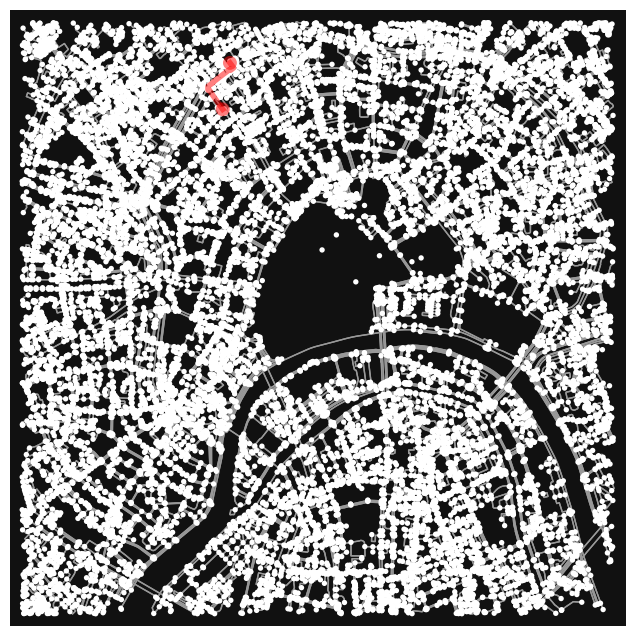

```
(<Figure size 800x800 with 1 Axes>, <Axes: >)
```

```python
ox.plot_graph_route(G, routes[1][0])
```

Для повышения производительности построения оптимального маршрута необходимо рассчитать все возможные маршруты между парковками и занести в базу данный, откуда в последующем брать данны по длине маршрута и точках маршрута